# Midpoint Deliverable

Daniel Chen, Grace Teebken, Tanner Lauzon, Kellen Maier

05/26/2020

## Introduction

This project will focus on the impacts of **global climate change** by considering *temperature changes* and changes in *natural disaster events*. We aim to visualize trends in global disasters and temperature data to reveal potential solutions to mitigate and reverse its impacts. Furthermore, our analyses will help illuminate areas that have been differentially impacted by climate change, this will allow us to allocate resources accordingly. We hope that this project will lead to greater awareness of the extent of climate change impacts as well as an understanding of which areas need the most attention and resources for combating the effects of climate change. In our previous brainstorming assignment we gathered three different dataset sources and in this midpoint deliverable we will be focusing on the [**temperature data on a global and country level dataset**](https://www.kaggle.com/berkeleyearth/climate-change-earth-surface-temperature-data) and the [**yearly counts and economic damage of natural disasters dataset**](https://www.kaggle.com/dataenergy/natural-disaster-data#number-of-natural-disaster-events.csv) (the dataset names link to the original websites that host the dataset). In the following *data cleaning* section we will go over how we combine these datasets and extract different subsets of data to do further analyses.

## Data Cleaning

We will be examining **two datasets** for this deliverable. The first consists of *average land temperatures per country*. The other consists of a combination of *yearly global average land temperatures* and *yearly count and total damages of natural disaster events*. We have already gathered the necessary data cleaning functions in `{r setup}` from `scripts/data_cleaning.R` and below we first gather all of the seperate csv files and load them in as dataframes.

```r
# DATASET 1
# gather average land temperature by country
avg_temp_by_country <-
  read.csv("data/kaggle_global_temp/GlobalLandTemperaturesByCountry.csv",
           stringsAsFactors = FALSE)

# DATASET 2
# gather global temperature averages
global_temp <-
  read.csv("data/kaggle_global_temp/GlobalTemperatures.csv",
           stringsAsFactors = FALSE)

# gather natural disaster counts
natural_disaster_count <-
  read.csv("data/kaggle_natural_disaster/number-of-natural-disaster-events.csv",
           stringsAsFactors = FALSE)

# gather natural disaster USD damages
natural_disaster_damage <-
  read.csv("data/kaggle_natural_disaster/damage-from-natural-disasters.csv",
           stringsAsFactors = FALSE)
```

We then clean up and combine the individual dataframes to get our final datasets that we will be using in our further analyses.

```r
# DATASET 1
# get clean average temperature by country dataset
avg_country_temp_data <-
  get_clean_avg_country_temp(avg_temp_by_country)

# DATASET 2
# get clean combined natural disaster count, damage, and temp dataset
natural_disaster_data <-
  get_clean_natural_disaster(global_temp,
                             natural_disaster_count,
                             natural_disaster_damage)
```

## Summary Information

We can now gather some brief summary information about our two datasets. First, we look at our dataset 1, the average country temperature dataset, and look into the number of observations, its breadth in terms of coverage by years and regions, and some key facts about the dataset.

```r
# gather summary info for DATASET 1 - average country temperature
temp_summary_info <- get_summary_info_temp(avg_country_temp_data)
temp_summary_info
```

```
## $length
## [1] 544811
##
## $range
##   max_year min_year
## 1     2013     1743
##
## $n_regions
## [1] 241
##
## $country_highest_all_years
##         date avg_temp avg_temp_se region year month
## 1 2012-07-01   38.842       0.464 Kuwait 2012     7
##
## $country_highest_after_1988
##         date avg_temp avg_temp_se region year month
## 1 2012-07-01   38.842       0.464 Kuwait 2012     7
##
## $country_highest_before_1988
##         date avg_temp avg_temp_se region year month
## 1 1921-07-01   37.642       1.992 Kuwait 1921     7
```

Our first dataset, which has average land temperatures by country, has **544,811 measurements** from **1743 to 2013**. It provides data for **241 countries and territories**. The country with the highest average land temperature for all years is **Kuwait** with an average land temperature of **38.8 ˚C** as measured for the monthly average land temperature of the 7th month of 2012.

In 1988, Dr. James Hansen [testified to Congress](https://www.nytimes.com/1988/06/24/us/global-warming-has-begun-expert-tells-senate.html) that global warming was “99 percent certain” and that the world needed to take action to prevent climate disaster. His testimony put a spotlight on the topic of climate change, and since then, climate change has been an important issue. This important year marks the point at which the American public became aware of the dangers of climate change and realized that action needed to be taken.

As such, we find it important to examine this dataset via two angles, before or during 1988 and after 1988, and identify the countries with the highest average land temperatures to examine potential impacts of his speech. Considering years before and including 1988, the country with the highest average temperature was **Kuwait** with an average land temperature of **37.6 ˚C** as measured for the monthly average land temperature of the 7th month of 1921. Considering years after 1988, the country with the highest average temperature was **Kuwait** with an average land temperature of **38.8 ˚C** as measured for the monthly average land temperature of the 7th month of 2012. Interestingly, Kuwait is the country that holds the highest monthly average land temperature for both before or during 1988 and after 1988 even though it does not exactly land on the equator. Unfortunately, it appears that Dr. James Hansen’s speech did not halt or reverse the impact of climate change. Furthermore, while considering years before or during 1988 the highest temperature was recorded in 1921. If we were expecting temperatures to continously increase over time we should expect the highest temperatures in the before or during 1988 time range to occur near 1988, yet it occurs in 1921 more than 60 years before our cutoff. Perhaps there was a fluke natural event that caused the monthly temperature to shoot up, but this is all just speculation and we cannot be too sure of any hypothesis without further testing. However, for the post 1988 time range, our highest monthly mean land temperature recording was in 2012 which is fairly close to the cutoff of 2013, our latest year in that time range, which does correspond with the idea that a continous increase in temperature over time should place the highest temperature measurment as late as possible. Of note, is the month of all of these measurments, all three (all years, before or during 1988, and after 1988) of these time ranges have their highest measurments in July, the 7th month, as such it may be interesting to group by the year and average the temperature across months to mitigate monthly variation and examine if the spike in July temperature also indicates an increase in the yearly temperature.

We can then gather some summary information, shown below, from the second dataset, count and damage caused by natural disasters along with their associated global land temperatures. Similarly to the previous summary information we look at the *number of observations* in this dataset along with its breadth in terms of *coverage by years*. Furthermore, we find the years with the *highest economic damage* by natural disasters, *highest number of natural disasters*, *highest natural disaster impact* (defined as damage / impact for each natural disaster event) and years with the *highest associated global mean land temperature*. To do this, we only look only at the rows with *All natural disasters* as the `disaster` type in order to give a broad overview of all natural disasters without having to compare between all of the individual natural disasters.

```r
# gather summary info for DATASET 2 - natural disaster count, damage,
#   and associated global temperature
disaster_summary_info <- get_summary_info_disaster(natural_disaster_data)
disaster_summary_info
```

```
## $length
## [1] 534
##
## $range
##   max_year min_year
## 1     2015     1900
##
## $year_highest_temp
##                disaster year      damage count mean_land_ocean_temp
## 1 All natural disasters 2015 84120138000   380             16.05858
##   mean_land_temp
## 1          9.831
##
## $year_highest_count
##                disaster year       damage count mean_land_ocean_temp
## 1 All natural disasters 2005 214205351000   432             15.87925
##   mean_land_temp
## 1       9.700917
##
## $year_highest_economic_damage
##                disaster year       damage count mean_land_ocean_temp
## 1 All natural disasters 2011 364093168000   334              15.7695
##   mean_land_temp
## 1          9.516
##
## $year_highest_impact
##                disaster year       damage count mean_land_ocean_temp
## 1 All natural disasters 2011 364093168000   334              15.7695
##   mean_land_temp     impact
## 1          9.516 1090099305
```

## Aggregate Table

Next, we look at our dataset 1, the average land temperature, via an aggregate table, shown below, to examine how temperatures differed and changed across time. To examine this dataset we consider three chunks of time, an **ancient** time period from *1842 to 1872*, a **past** time period from *1912 to 1942*, and a **present** time period from *1982 to 2012*. We will examine the average temperatures in ˚C for each of these time period and how temperature has *changed between the past and ancient, and the present and past time periods*. Then we can examine the *overall change in temperature*, of which we will sort this dataframe by, to look at regins that were most impacted (i.e. changed the most across time). Furthermore we compute the *difference between the change in temperature from the past to present time periods and the change in temperature from the ancient to past time periods*. This allows us to see if, recently, temperatures have been changing faster than normal.

```r
# gather aggregate table for DATASET 1 - average country temperature
temp_aggr_table <- get_aggr_table_temp(avg_country_temp_data)
kable(temp_aggr_table)
```

| Region | Ancient Mean Land Temperature (ËšC) | Past Mean Land Temperature (ËšC) | Present Mean Land Temperature (ËšC) | Previous Change in Mean Land Temperature (ËšC) | Recent Change in Mean Land Temperature (ËšC) | Overall Change in Mean Land Temperature (ËšC) | Change Between Recent and Previous Changes (ËšC |
| --- | --- | --- | --- | --- | --- | --- | --- |
| East Asia & Pacific | 18.793 | 21.336 | 22.021 | 2.543 | 0.685 | 3.228 | -1.858 |
| Middle East & North Africa | 21.040 | 22.409 | 23.173 | 1.369 | 0.764 | 2.133 | -0.605 |
| North America | 2.168 | 2.678 | 3.458 | 0.510 | 0.780 | 1.290 | 0.270 |
| Europe & Central Asia | 7.463 | 7.754 | 8.578 | 0.291 | 0.824 | 1.115 | 0.533 |
| Sub-Saharan Africa | 23.772 | 24.271 | 24.864 | 0.500 | 0.593 | 1.093 | 0.093 |
| South Asia | 19.151 | 19.545 | 20.212 | 0.394 | 0.667 | 1.061 | 0.272 |
| Latin America & Caribbean | 24.491 | 24.229 | 24.929 | -0.262 | 0.700 | 0.438 | 0.962 |

When looking at the table above we see that the *East Asia & Pacific* region of the world has the greatest overall change in mean land temperature. However, they have appeared to slow down the rate at which their average temperature increases, as seen in the `Changes Between Recent and Previous Changes (˚C)` column, where they have a value of -1.858 ˚C, meaning that their most recent change (past to present) in temperature is 1.858 ˚C smaller than their previous change (ancient to past) in temperature. In addition, the *Middle East & North Africa* region has the second highest overall change in mean land temperature and also has a negative change between their previous and recent change in temperatures. It would be interesting to see if there are reasons why these two regions have decreased their rate of increase in temperature across time, perhaps the countries in the respective areas are pushing hard on environmental fronts but we cannot be sure until further research is done. However, even though some of these regions are decreasing in their rate of temperature increase across time they all have positive overall changes in mean land temperature meaning all of these regions are increasing their mean land temperature across time. Another point of interest is that, while the *Latin America & Caribbean* region has the lowest overall change in mean land temperature it has the highest change between its recent and previous change in temperatures. This tells us that it has recently shot up in the rate at which it increases its mean land temperature, and it would be interesting to understand why, as its previous change from the ancient and previous time periods was negative.

We then examine our dataset 2, the combined natural disaster dataset via an aggregate table, shown below, to view how natural disasters have *changed* both in their number of *occurrences*, their total *damage*, and how *global temperatures* have also changed. Using an average of **30 years in the past**, *1912 to 1942*, and an average of **30 years in the present**, *1982 to 2012*, we compute the change in count and damage of natural disasters, and the associated change in global mean land and land+ocean temperatures. Furthermore, we computed the *impact* of each natural disasters by dividing its damage for the year by the number of occurrences. This provides us with a quantitative measurment for the amount of damage the natural disaster causes per incident, and allows us to examine if a disaster is causing more damage per incident as time goes on. This aggregate table is then sorted from highest to lowest, descending order, by the *difference in economic damage* to focus on which types of natural disasters cause the greatest yearly damage on average.

```r
# gather aggregate table for DATASET 2 - natural disaster count, damage,
#   and associated global temperature
disaster_aggr_table <- get_aggr_table_disaster(natural_disaster_data)
kable(disaster_aggr_table)
```

| Disaster Type | Difference in Count | Difference in Economic Damage (billions of USD) | Difference in Impact (billions of USD / count) | Difference in Mean Land Temperature (ËšC) | Difference in Mean Land+Ocean Temperature (ËšC) |
| --- | --- | --- | --- | --- | --- |
| All natural disasters | 278.419 | 76.670 | 0.231 | 0.526 | 0.715 |
| Extreme weather | 82.537 | 28.835 | 0.268 | 0.551 | 0.732 |
| Earthquake | 21.148 | 22.421 | 0.800 | 0.479 | 0.680 |
| Flood | 111.328 | 17.834 | -0.117 | 0.469 | 0.638 |
| Wildfire | 10.036 | 1.840 | 0.182 | 0.674 | 0.999 |
| Volcanic activity | 4.733 | 0.121 | 0.027 | 0.530 | 0.574 |

As shown in the table above, we have also included the **All natural disasters** row as it gives an easier summary of how the total count and damage of natural disasters have changed throughought time, along with their associated change in global mean temperatures. We can see from this **All natural disasters** row that not only has the global temperature increased, but the number of natural disasters along with their total yearly damage and impact (damage per incident) have also increased as well. While, **extreme weather** is the natural disaster with the *greatest increase in economic damage* (increased by ~28.8 billions of USD), earthquakes have the highest change in impact. This means that in the most recent 30 years, 1982 to 2012, **earthquakes** are now causing *significantly more damage per event* (increased by ~800 million per incident) than the past group of 30 years, 1912 to 1942. Of further concern is the universal increase in count of natural disasters, while **floods** have actually *decreased in impact*, perhaps we are now better equipped to mitigate its damage, they have *severely increased in the number of average occurrences per year*. Overall, we can see that natural disasters, along with global temperatures, have increased both in their count and damage across time.

## Data Visualizations

In our first chart we aim to provide a broad overview of how our overall climate, measured via mean land temperature, has changed for, around, the past 100 years. We accomplish this by using dataset 1, mean land temperature by country, to plot a heatmap of the change in mean land temperature from 1912 to 2012 layered on a world map to show the relative changes of different countries, as shown below.

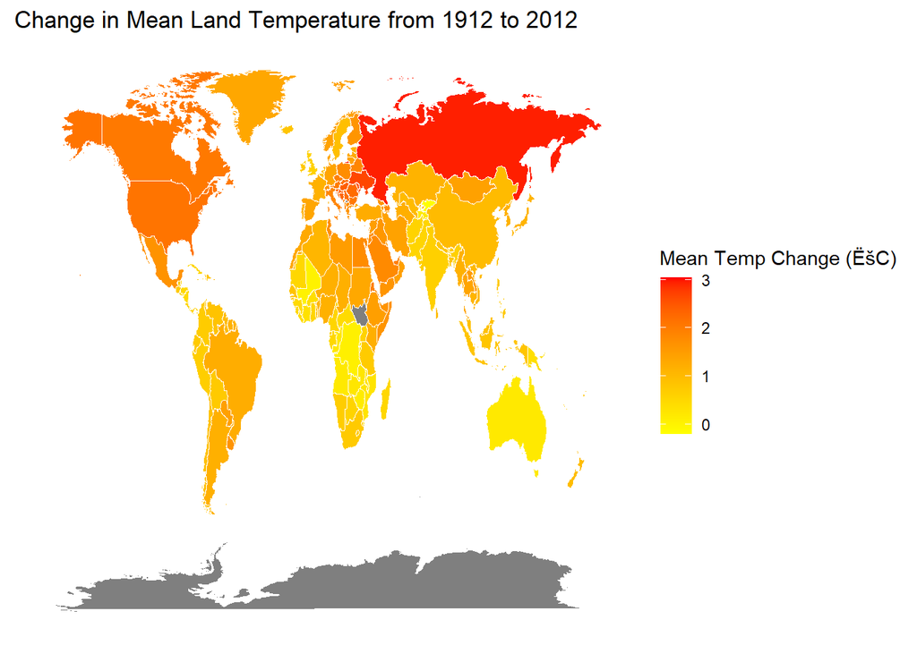

```r
# plot 1 - heatmap of dataset 1 on world map
world_map_temp_change(avg_country_temp_data)
```

The changes shown in the map above seem to closely follow the `Recent Change in Mean Land Temperature (˚C)` column in our previously shown aggregate table for dataset 1. This is shown via a greater increase in temperature in the Europe & Central Asia (which we consider Russia to be in) row in the aggregate table and region on the map. Russia and its western neighboring countries emphasize this point the most, as they have the greatest increase (~2-3 ˚C) in mean land temperature. Interestingly, the Southern Hemisphere appears to have been impacted less than the Northern Hemisphere in terms of a universally smaller increase in mean land temperature in response to the rapid climate change in the recent years. This also correlates, as it should because it is the same dataset, to our previous aggregate table where we see relatively smaller values in the `Recent Change in Mean Land Temperature (˚C)` column for regions in the Southern Hemisphere and relatively larger values for regions in the Northern Hemisphere. The reason why we see correlations to the recent changes rather than the previous changes column is because the recent changes column covers averaged temperatures across the time periods of 1912-1942 and 1982-2012 which corresponds quite closely to our cutoffs of 1912 and 2012 in this plot. As such, we should expect any hypotheses that are drawn from the recent change column to correlate well with the hypotheses drawn from this plot. Furthermore, we noted in the aggregate table that the East Asia & Pacific and Middle East & North Africa regions had a decrease in their rate of temperature increase between their most recent (between past and present) and previous changes (between ancient and past) in temperature but had the highest overall change in temperature (between ancient and present). While not apparently obvious, we can see these observations in the heatmap, the above plot, as well. The specified regions are still partially high in their change in mean land temperature, which we can call an artifact of their previous rapid increase in temperature, but due to their recent decrease in their temperature increase they are not the regions with the greatest recent increase in mean land temperature. Overall, we can see how universally each of these countries have had a recent increase in their mean land temperature and how there is a differentially high rate of temperature increase in Northern regions.

In our second chart, shown below, we examine our second dataset via the change in the counts of different disaster types across time. This plot allows us to quickly see how the number of occurrences per disaster changes across time, and if different disasters are differentially impacted. We will also plot an “All natural disasters” line in order to see the general trend of natural disaster occurrences over time, it is essentially the sum of all of the minor lines.

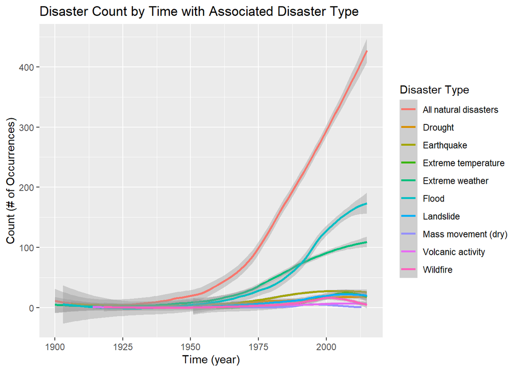

```r
# plot 2 - trendlines of different disaster occurrences in dataset 2 across time
trendline_nd_count_by_year(natural_disaster_data)
```

As seen above, via the “All natural disasters” line, the count of natural disasters per year have generally shot up after 1950. Before 1950, the line remained steadily near 0, but after 1950 the line has a steady linear increase resulting in over 400 natural disasters occurring in the latest year. However, this is just a general trend and in order to better understand how individual natural disasters contribute to this general trend we look at the lines for each type of natural disaster. By looking at individual natural disasters we can see that “Flood” and “Extreme weather” dominate as the natural disasters with the greatest increase in occurrences per year. Perhaps these are more affected by the recent increase in temperature, but we cannot be entirely sure until we examine these two pieces of data directly, which will be done below in plot 3. While it may seem that the other disasters have remained relatively near 0 in the recent years we cannot definitively claim that because we are plotting all of these lines on the same axes so any minute changes get overshadowed by the larger changes of other types of natural disasters. Furthermore, while these trendlines allow us to get an idea of how the count of natural disasters is shifting over time, they are still an estimate and are not entirely accurate. However, even though trendlines are just an estimate we do believe that they provide a useful guide in showing how natural disaster count has been changing across the years and are more clear than a scatter plot which may distract the viewer via random outliers. In addition, this graph does not depict the “Impact” natural disaster, because there has only been a single year within this time frame where an “Impact” has occurred so we cannot draw a trendline for this natural disaster with a singular point. Overall, we can see how each of these *estimates* seem to point to an increase in natural disaster occurrences over time.

To compound on the analysis done above, we investigate the impacts of mean land temperature on the number of occurrences of each natural disaster. This allows us to see how temperature correlates with the count of natural disasters. To also visualize how the damage caused by these disasters correlates with both the count of natural disasters and the mean land temperature we color a normalized version of the economic damage column onto the scatter plots. While previously we chose a trendline to show a clean guide of how different natural disasters have changed across time, for this plot we will utilize scatterplots, shown below. As we have a plot per natural disaster, the number of points per plot have significantly decreased, and we no longer have to worry about points from different natural disasters overlapping with each other. Furthermore, with both less points and seperated disaster types, we want to see outliers as they are more important because they can indicate “special” data points that may peak our interest.

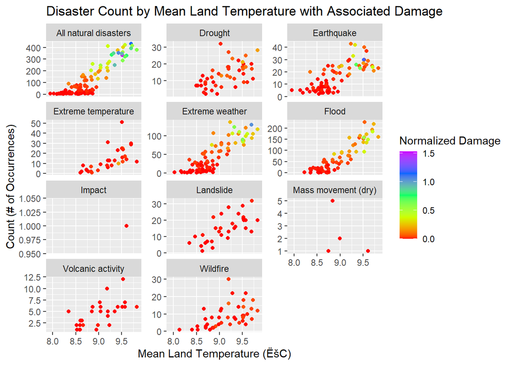

```r
# plot 3 - different disaster occurrences in dataset 2 by mean land temperature
#          with associated normalized economic damage (x / 1e11 then log1p)
scatter_nd_count_by_temp(natural_disaster_data)
```